# Exercise8

Matthew Reynolds

2023-04-19

**Question:**  
We will now perform cross-validation on a simulated data set. (a) Generate a simulated data set as follows:

```r
set.seed(1)
x=rnorm(100)
y=x-2*x^2+rnorm(100)
```

In this data set, what is n and what is p? Write out the model used to generate the data in equation form.

2. Create a scatterplot of X against Y . Comment on what you find.

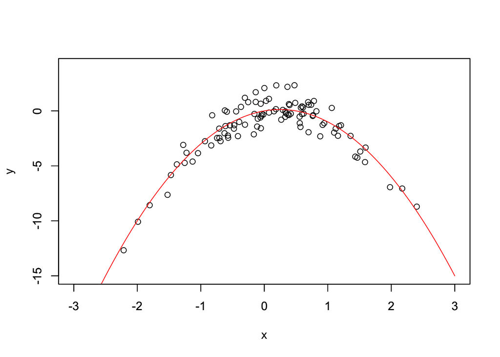

```r
plot(x, y, xlim = range(-3:3), ylim = range(-15:4))
par(new = TRUE)
curve(x - 2*x^2, from = -3, to = 3, xlim = range(-3:3), ylim = range(-15:4), xlab = "", ylab = "", col = "red")
```

X has a negative quadratic relationship to Y. Peaking around x = 0.2, y = 0.

3. Set a random seed, and then compute the LOOCV errors that result from fitting the following four models using least squares:
1. Y = β0 + β1X + ε
2. Y = β0 + β1X + β2X2 + ε
3. Y = β0 +β1X +β2X2 +β3X3 +ε
4. Y = β0 +β1X +β2X2 +β3X3 +β4X4 +ε. Note you may find it helpful to use the data.frame() function to create a single data set containing both X and Y .

```r
set.seed(499)
xy.data = data.frame("pred" = x, "resp" = y)

deg1.fit = glm(resp ~ pred, data = xy.data)
deg1.err = cv.glm(xy.data, deg1.fit)
cat("The LOOCV of Option I is: ", deg1.err$delta[1], "\n")
```

```
## The LOOCV of Option I is:  7.288162
```

```r
deg2.fit = glm(resp ~ poly(pred, 2), data = xy.data)
deg2.err = cv.glm(xy.data, deg2.fit)
cat("The LOOCV of Option II is: ", deg2.err$delta[1], "\n")
```

```
## The LOOCV of Option II is:  0.9374236
```

```r
deg3.fit = glm(resp ~ poly(pred, 3), data = xy.data)
deg3.err = cv.glm(xy.data, deg3.fit)
cat("The LOOCV of Option III is: ", deg3.err$delta[1], "\n")
```

```
## The LOOCV of Option III is:  0.9566218
```

```r
deg4.fit = glm(resp ~ poly(pred, 4), data = xy.data)
deg4.err = cv.glm(xy.data, deg4.fit)
cat("The LOOCV of Option IV is: ", deg4.err$delta[1], "\n")
```

```
## The LOOCV of Option IV is:  0.9539049
```

4. Repeat (c) using another random seed, and report your results. Are your results the same as what you got in (c)? Why?

```r
set.seed(3)
xy.data = data.frame("pred" = x, "resp" = y)

deg1.fit = glm(resp ~ pred, data = xy.data)
deg1.err = cv.glm(xy.data, deg1.fit)
cat("The LOOCV of Option I is: ", deg1.err$delta[1], "\n")
```

```
## The LOOCV of Option I is:  7.288162
```

```r
deg2.fit = glm(resp ~ poly(pred, 2), data = xy.data)
deg2.err = cv.glm(xy.data, deg2.fit)
cat("The LOOCV of Option II is: ", deg2.err$delta[1], "\n")
```

```
## The LOOCV of Option II is:  0.9374236
```

```r
deg3.fit = glm(resp ~ poly(pred, 3), data = xy.data)
deg3.err = cv.glm(xy.data, deg3.fit)
cat("The LOOCV of Option III is: ", deg3.err$delta[1], "\n")
```

```
## The LOOCV of Option III is:  0.9566218
```

```r
deg4.fit = glm(resp ~ poly(pred, 4), data = xy.data)
deg4.err = cv.glm(xy.data, deg4.fit)
cat("The LOOCV of Option IV is: ", deg4.err$delta[1], "\n")
```

```
## The LOOCV of Option IV is:  0.9539049
```

The LOOCV are the exact same for both of my seeds. This is because LOOCV doesn’t involve any randomness which could change the results.

5. Which of the models in (c) had the smallest LOOCV error? Is this what you expected? Explain your answer.